# Publication Results - Final?

## 1. Forensic Anthropologists

```r
## Import Dataset
fa_base <- read_excel('ANTH salary data 6_EYC.xlsx', sheet='All FAs')

## Edit Data
fa <- fa_base[,-c(1:2)]  # remove names
fa <- fa[-61,]  # remove special focus four-year
colnames(fa) <- c('Sex','ABFA_Cert','Term_Deg','Deg_Year','Grad_Inst','Type','Lab_Time','Basic_Class','Rank','Admin','Salary_Index')  # rename columns
fa$Admin[is.na(fa$Admin)] <- 0
factor_cols <- c('Sex','ABFA_Cert','Term_Deg','Grad_Inst','Type','Lab_Time','Basic_Class','Rank','Admin')  # identify categorical variables
fa[factor_cols] <- lapply(fa[factor_cols],factor)  # factor categorical variables
fa$Basic_Class <- factor(fa$Basic_Class, levels=c("NA","Associate's Colleges","Baccalaureate College","Master's Colleges & Universities","Doctoral Universities"))
fa$Rank <- recode(fa$Rank, "Applied"="NA","Assistant Professor"="Assistant Professor","Associate Professor"="Associate Professor", "Dean" = "Special Rank", "Director" = "Special Rank", "Distinguished University Professor"="Special Rank","Full Professor"="Full Professor","Regents Professor"="Special Rank","Term"="Term")  # Special Rank == Dean, Distinguished, Regents, Director, President
fa$Rank <- factor(fa$Rank, levels=c("NA","Term","Assistant Professor","Associate Professor","Full Professor","Special Rank"))
fa$Lab_Time <- factor(fa$Lab_Time, levels=c("NA","Part","Full"))
fa <- mutate(fa, Active_Years = 2019-Deg_Year)
fa <- fa[,-4]  # remove degree year

## Separate SI values into previously established categories: One, Two, Three, Four
SI_Cat <- NULL
for(i in 1:nrow(fa)){
  if(fa$Salary_Index[i] >= breaks[1] & fa$Salary_Index[i] < breaks[2]){
    SI_Cat[i] = 'One'
  } else if(fa$Salary_Index[i] >= breaks[2] & fa$Salary_Index[i] < breaks[3]){
    SI_Cat[i] = 'Two'
  } else if(fa$Salary_Index[i] >= breaks[3] & fa$Salary_Index[i] < breaks[4]){
    SI_Cat[i] = 'Three'
  } else{
    SI_Cat[i] = 'Four'
  }
}

fa <- cbind(fa, SI_Cat)
fa$SI_Cat <- factor(fa$SI_Cat, levels=c('One','Two','Three','Four'))
write.csv(fa,'FA_Only.csv')
summary(fa)
```

```
##  Sex    ABFA_Cert Term_Deg                               Grad_Inst
##  F:74   N:71      MA : 14   University of Tennessee, Knoxville:29
##  M:40   Y:43      PhD:100   University of Florida             :11
##                             Ohio State University             : 8
##                             University of Arizona             : 6
##                             Michigan State University         : 5
##                             University of Chicago             : 4
##                             (Other)                           :51
##        Type    Lab_Time                            Basic_Class
##  Academic:77   NA  :77   NA                              :37
##  Applied :37   Part:19   Associate's Colleges            : 2
##                Full:18   Baccalaureate College           : 3
##                          Master's Colleges & Universities:20
##                          Doctoral Universities           :52
##
##
##                   Rank    Admin    Salary_Index     Active_Years     SI_Cat
##  NA                 :37   0:101   Min.   : 27.66   Min.   : 1.00   One  :43
##  Term               :14   1: 13   1st Qu.: 59.96   1st Qu.: 7.25   Two  :35
##  Assistant Professor:25           Median : 76.34   Median :14.50   Three:19
##  Associate Professor:15           Mean   : 80.97   Mean   :17.17   Four :17
##  Full Professor     :20           3rd Qu.: 97.42   3rd Qu.:24.75
##  Special Rank       : 3           Max.   :168.61   Max.   :47.00
##
```

Now, we can see the distribution of SI Categories from the summary.

Before conducting any actual analysis, let’s look at our data and see what interesting trends we may see…

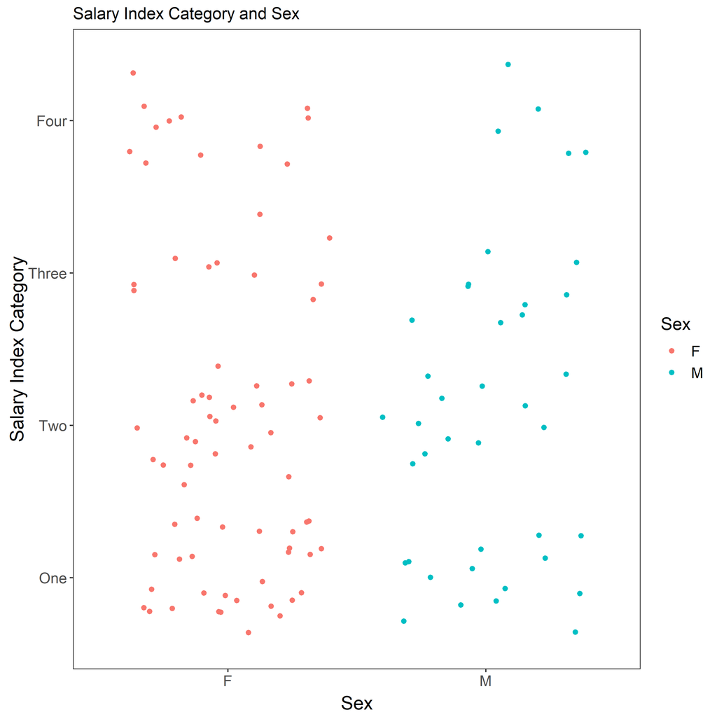

```r
## Jitter plot comparing SI_Cat to Sex
ggplot(fa, aes(x=Sex, y=SI_Cat, color=Sex)) + geom_jitter() + kyra_theme + ylab('Salary Index Category') + ggtitle('Salary Index Category and Sex')
```

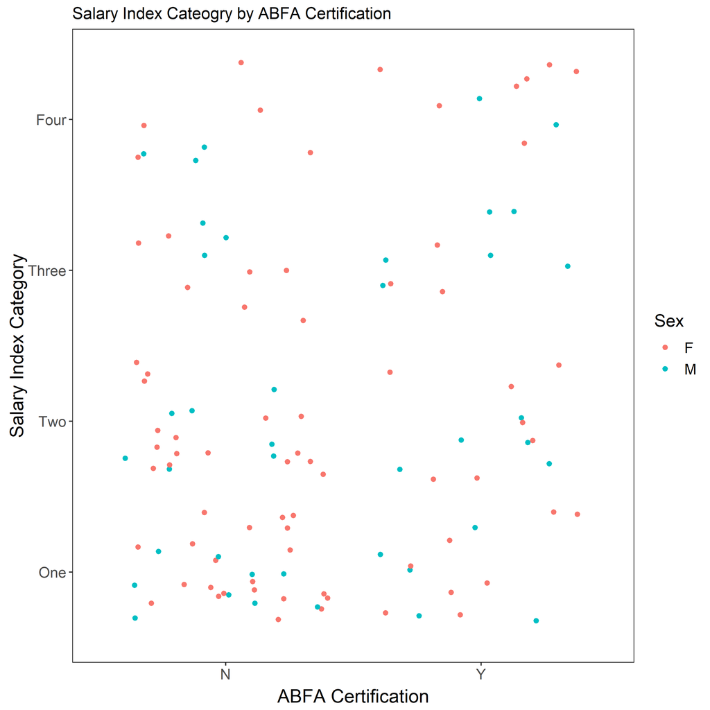

```r
## Jitter plot comparing SI_Cat to ABFA_Certification
ggplot(fa, aes(x=ABFA_Cert, y=SI_Cat, color=Sex)) + geom_jitter() + kyra_theme + ylab('Salary Index Category') + xlab('ABFA Certification') + ggtitle('Salary Index Cateogry by ABFA Certification')
```

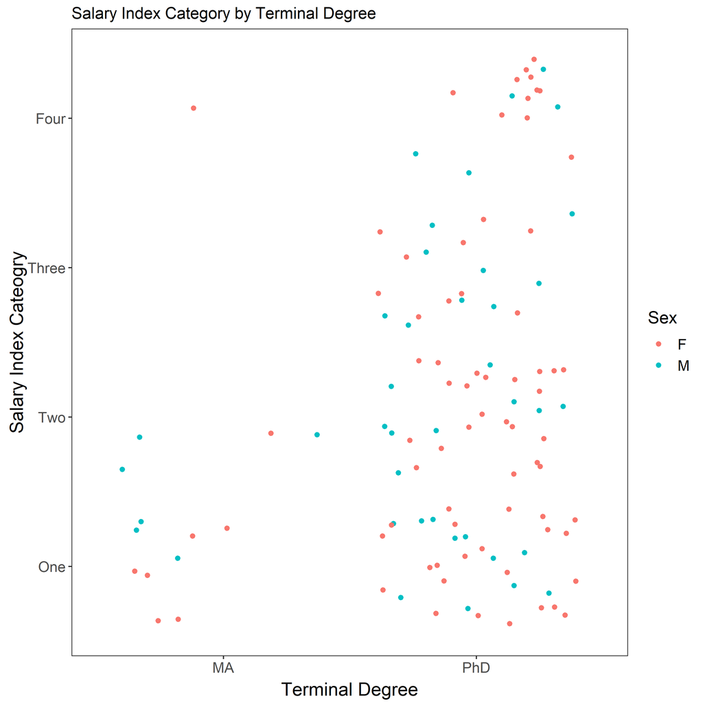

```r
## Jitter plot comparing SI_Cat to Terminal Degree
ggplot(fa, aes(x=Term_Deg, y=SI_Cat, color=Sex)) + geom_jitter() + kyra_theme + ylab('Salary Index Cateogry') + xlab('Terminal Degree') + ggtitle('Salary Index Category by Terminal Degree')
```

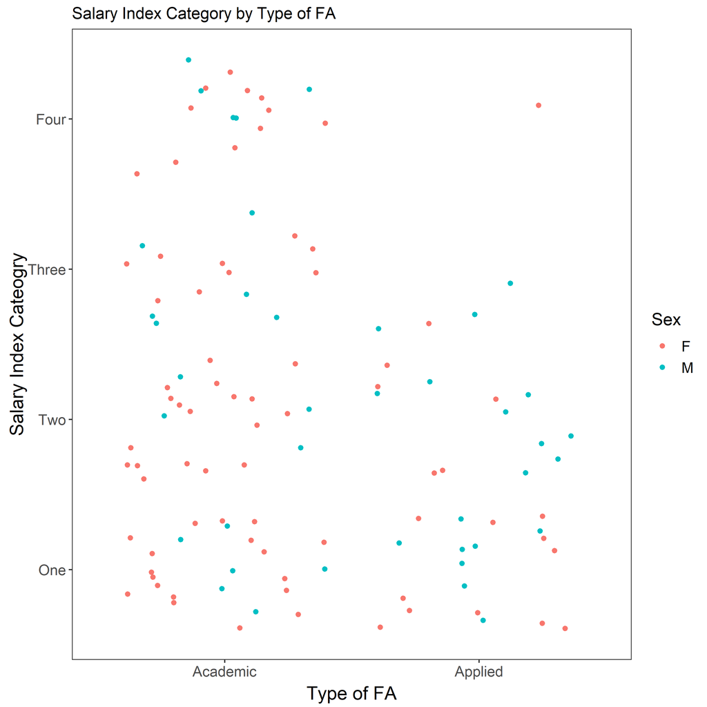

```r
## Jitter plot comparing SI_Cat to Type of FA
ggplot(fa, aes(x=Type, y=SI_Cat, color=Sex)) + geom_jitter() + kyra_theme + ylab('Salary Index Cateogry') + xlab('Type of FA') + ggtitle('Salary Index Category by Type of FA')
```

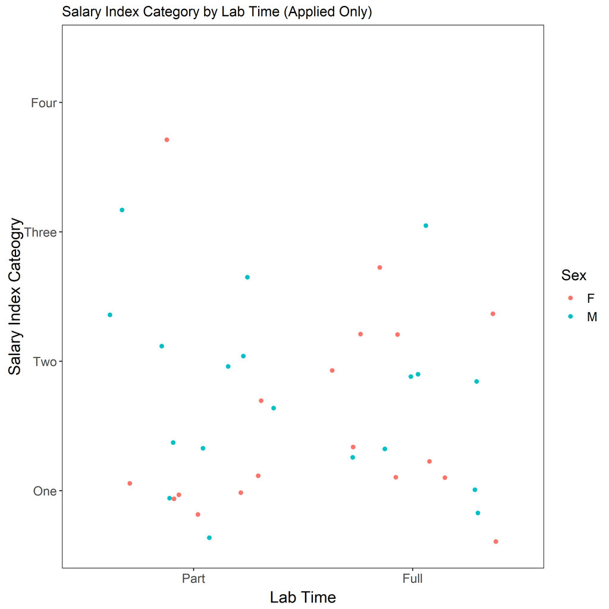

```r
## Jitter plot comparing SI_Cat to Lab Time (Applied Only)
ggplot(subset(fa, Type=='Applied'), aes(x=Lab_Time, y=SI_Cat, color=Sex)) + geom_jitter() + kyra_theme + ylab('Salary Index Cateogry') + xlab('Lab Time') + ggtitle('Salary Index Category by Lab Time (Applied Only)')
```

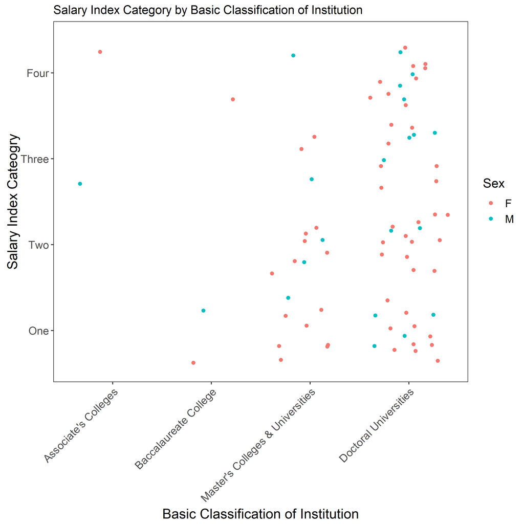

```r
## Jitter plot comparing SI_Cat to Basic Classification (Academic Only)
ggplot(subset(fa, Type=='Academic'), aes(x=Basic_Class, y=SI_Cat, color=Sex)) + geom_jitter() + kyra_theme + ylab('Salary Index Cateogry') + xlab('Basic Classification of Institution') + ggtitle('Salary Index Category by Basic Classification of Institution') + theme(axis.text.x=element_text(angle=45,hjust=1))
```

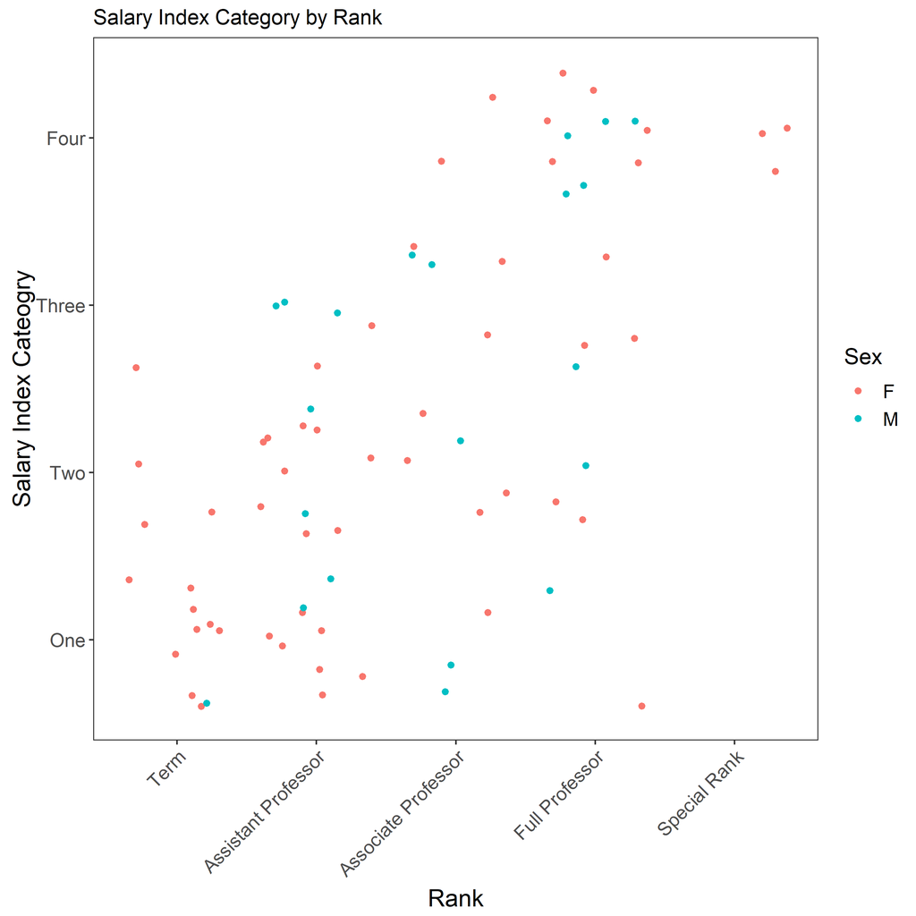

```r
## Jitter plot comparing SI_Cat to Rank (Academic Only)
ggplot(subset(fa, Type=='Academic'), aes(x=Rank, y=SI_Cat, color=Sex)) + geom_jitter() + kyra_theme + ylab('Salary Index Cateogry') + xlab('Rank') + ggtitle('Salary Index Category by Rank') + theme(axis.text.x=element_text(angle=45,hjust=1))
```

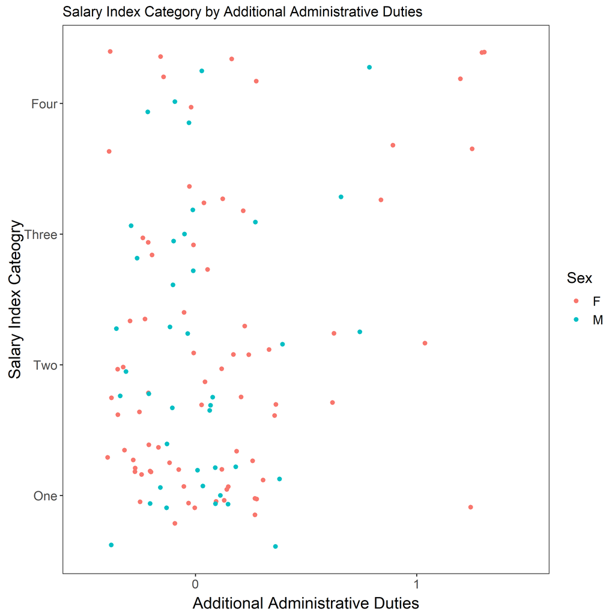

```r
## Jitter plot comparing SI_Cat to Admin
ggplot(fa, aes(x=Admin, y=SI_Cat, color=Sex)) + geom_jitter() + kyra_theme + ylab('Salary Index Cateogry') + xlab('Additional Administrative Duties') + ggtitle('Salary Index Category by Additional Administrative Duties')
```

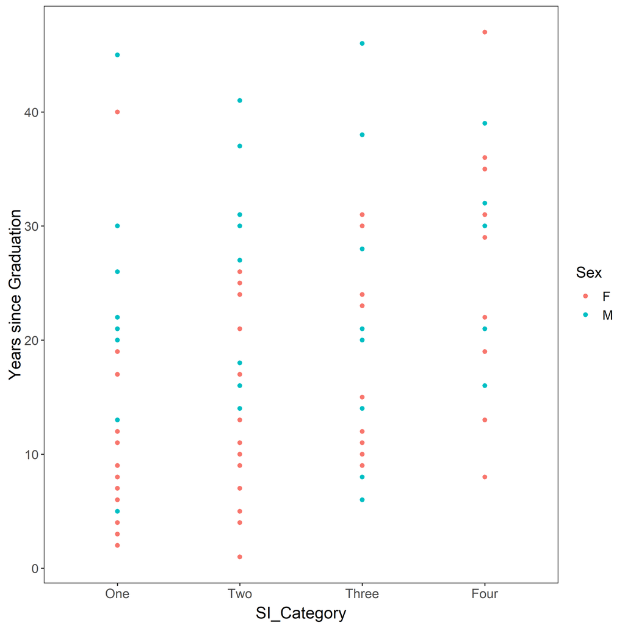

```r
## Bar plot comparing SI_Cat to Active Years
ggplot(fa, aes(x=SI_Cat, y=Active_Years, color=Sex)) + geom_point() + kyra_theme + ylab('Years since Graduation') + xlab('SI_Category')
```

So, to back up our visuals with actual statistics, let’s see if we can statitsically compute any associations between our variables and SI categories. For this, we’re going to try out Cramer’s V because it can handle bigger than 2x2 tables, and is based off of Pearson’s Correlation(?).

```r
##SI_Cat and Sex
SI_Sex <- as.matrix(rbind(c(14,29),c(21,31),c(5,14)))  # contingency table -- Trust Me
cramerV(SI_Sex, ci=TRUE)
```

```
##   Cramer.V lower.ci upper.ci
## 1   0.1109  0.03025    0.309
```

```r
## SI_Cat and ABFA
SI_ABFA <- as.matrix(rbind(c(13,30),c(21,31),c(9,10)))  # contingency table
cramerV(SI_ABFA, ci=TRUE)
```

```
##   Cramer.V lower.ci upper.ci
## 1   0.1303   0.0396   0.3294
```

```r
## SI_Cat and Term_Deg
SI_TD <- as.matrix(rbind(c(9,34),c(4,48),c(1,18)))  # contingency table
cramerV(SI_TD, ci=TRUE)
```

```
##   Cramer.V lower.ci upper.ci
## 1   0.2067  0.06196   0.3959
```

```r
## SI_Cat and Type
SI_Type <- as.matrix(rbind(c(19,24),c(17,35),c(1,18)))  # contingency table
cramerV(SI_Type, ci=TRUE)
```

```
##   Cramer.V lower.ci upper.ci
## 1   0.2827   0.1648   0.4423
```

```r
## SI_Cat and Lab_time
SI_LT <- as.matrix(rbind(c(10,9),c(8,9),c(1,0)))  # contingency table
cramerV(SI_LT, ci=TRUE)
```

```
##   Cramer.V lower.ci upper.ci
## 1   0.1713       NA       NA
```

```r
## SI_Cat and Basic_Class
SI_BC <- as.matrix(rbind(c(0,2,8,14),c(1,0,11,23),c(1,1,1,15)))  # contingency table
cramerV(SI_BC, ci=TRUE)
```

```
##   Cramer.V lower.ci upper.ci
## 1   0.2379       NA       NA
```

```r
## SI_Cat and Rank
SI_Rank <- as.matrix(rbind(c(10,9,3,2,0),c(4,16,9,6,0),c(0,0,3,12,3)))  # contingency table
cramerV(SI_Rank, ci=TRUE)
```

```
##   Cramer.V lower.ci upper.ci
## 1   0.5463       NA       NA
```

```r
## SI_Cat and Active_Years
SI_AY <- kruskal.test(fa$Salary_Index,fa$Active_Years)
SI_AY
```

```
##
##  Kruskal-Wallis rank sum test
##
## data:  fa$Salary_Index and fa$Active_Years
## Kruskal-Wallis chi-squared = 50.883, df = 41, p-value = 0.1386
```

Because UTK makes up 25% of our dataset, I want to remove UTK/Grad Institution from the analysis because it may bias our subsequent results…

#### RandomForest and Variable Importance

So, this is a new analysis that I figured I would try out after chatting with Kyra. RandomForest sets up multiple decision trees and provides a metric of Variable Importance for each variable. Also, we have a new dataset to play with! Yay!

Luckily, there is no danger in correlated traits with a Random Forest model, because the decision tree will take care of them by ranking one with higher importance and reducing the importance of the other variable(s) accordingly.

```r
RFM <- fa[,c(1:3,5:9,11,12)]  ## remove Salary_Index column

## Select best mtry value
set.seed(123)
mtry <- tuneRF(RFM[,c(1:9)],RFM$SI_Cat,ntreeTry=500,stepFactor=1.5,improve=0.01,trace=TRUE,plot=FALSE)
```

```
## mtry = 3  OOB error = 54.39%
## Searching left ...
## mtry = 2     OOB error = 54.39%
## 0 0.01
## Searching right ...
## mtry = 4     OOB error = 57.02%
## -0.0483871 0.01
```

```r
best.m <- mtry[mtry[,2]==min(mtry[,2]),1]
print(mtry)
```

```
##       mtry  OOBError
## 2.OOB    2 0.5438596
## 3.OOB    3 0.5438596
## 4.OOB    4 0.5701754
```

```r
print(best.m)
```

```
## 2.OOB 3.OOB
##     2     3
```

```r
set.seed(123)
rf <- randomForest(SI_Cat ~., data=RFM, importance=TRUE, mtry=2, ntree=500)
print(rf)
```

```
##
## Call:
##  randomForest(formula = SI_Cat ~ ., data = RFM, importance = TRUE,      mtry = 2, ntree = 500)
##                Type of random forest: classification
##                      Number of trees: 500
## No. of variables tried at each split: 2
##
##         OOB estimate of  error rate: 55.26%
## Confusion matrix:
##       One Two Three Four class.error
## One    24  14     4    1   0.4418605
## Two    16  15     3    1   0.5714286
## Three   7   8     0    4   1.0000000
## Four    1   3     1   12   0.2941176
```

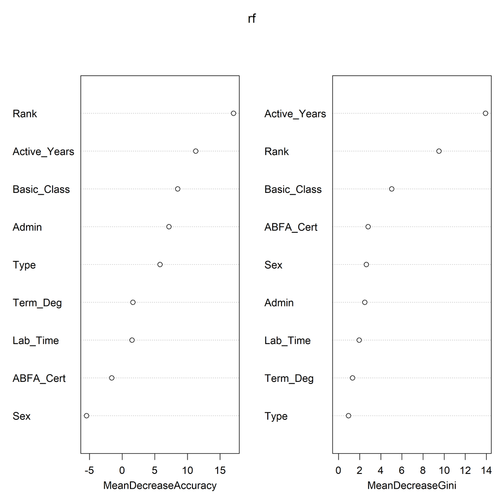

```r
write.csv(rf$confusion,'FA_cfm.csv')

## Variable Importance
varImpPlot(rf)
```

```r
importance(rf,type=2)
```

```
##              MeanDecreaseGini
## Sex                 2.6307102
## ABFA_Cert           2.8025825
## Term_Deg            1.3219636
## Type                0.9387449
## Lab_Time            1.9597994
## Basic_Class         5.0367260
## Rank                9.5162911
## Admin               2.4789907
## Active_Years       13.9150675
```

Classification accuracy for this model: 44.74%.. Take a look at the confusion matrix as well. We can see that Active Years, Rank, and Basic Classification are the most important variables, per the right plot and the ‘MeanDecreaseGini’ coefficients. Gini coefficient measures the ‘purity’ of nodes at each split (aka the homogeneity of classes). This is the measure we use when running a categorical RFM. It is interesting to note that 2 of the top 3 most important variables only relate to Academic FAs. This is probably due to the imbalance of samples, Academic vs. Applied.

Because the total number of samples for FAs only is 114, the sample isn’t large enough to build the model on a training set and testing on a test set. We *WILL* do this for the academic anthropologist sample!

### Academic FAs only

So now, we are going to split the dataset into Academic only and Applied only FAs. We’ll see if this improves the RFM model at all.

```r
edu <- filter(RFM, Type=="Academic")
edu <- edu[,c(1:3,6:10)]

summary(edu)
```

```
##  Sex    ABFA_Cert Term_Deg                           Basic_Class
##  F:56   N:48      MA : 2   NA                              : 0
##  M:21   Y:29      PhD:75   Associate's Colleges            : 2
##                            Baccalaureate College           : 3
##                            Master's Colleges & Universities:20
##                            Doctoral Universities           :52
##
##                   Rank    Admin   Active_Years     SI_Cat
##  NA                 : 0   0:64   Min.   : 2.00   One  :24
##  Term               :14   1:13   1st Qu.: 8.00   Two  :22
##  Assistant Professor:25          Median :15.00   Three:15
##  Associate Professor:15          Mean   :17.35   Four :16
##  Full Professor     :20          3rd Qu.:25.00
##  Special Rank       : 3          Max.   :47.00
```

#### RandomForest of Academic FAs only

```
## mtry = 2  OOB error = 59.74%
## Searching left ...
## Searching right ...
## mtry = 3     OOB error = 57.14%
## 0.04347826 0.01
## mtry = 4     OOB error = 62.34%
## -0.09090909 0.01
```

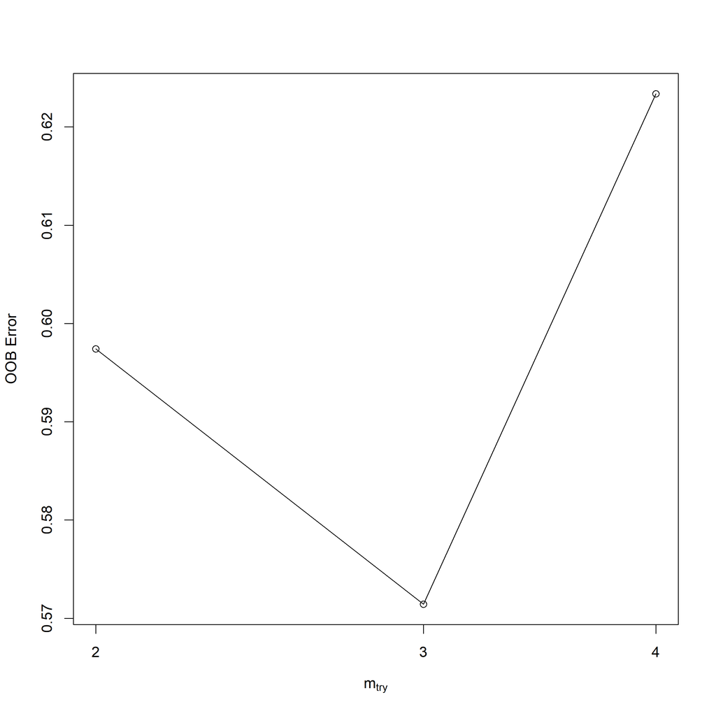

```r
set.seed(123)
## Select best mtry value
mtry2 <- tuneRF(edu[,-8],edu$SI_Cat,ntreeTry=500,stepFactor=1.5,improve=0.01,trace=TRUE,plot=TRUE)
```

```r
best.m2 <- mtry2[mtry2[,2]==min(mtry2[,2]),1]
print(mtry2)
```

```
##       mtry  OOBError
## 2.OOB    2 0.5974026
## 3.OOB    3 0.5714286
## 4.OOB    4 0.6233766
```

```r
print(best.m2)
```

```
## [1] 3
```

```r
set.seed(123)
rf2 <- randomForest(SI_Cat ~., data=edu, importance=TRUE, mtry=3, ntree=500)
print(rf2)
```

```
##
## Call:
##  randomForest(formula = SI_Cat ~ ., data = edu, importance = TRUE,      mtry = 3, ntree = 500)
##                Type of random forest: classification
##                      Number of trees: 500
## No. of variables tried at each split: 3
##
##         OOB estimate of  error rate: 58.44%
## Confusion matrix:
##       One Two Three Four class.error
## One    11   8     4    1   0.5416667
## Two     7   9     5    1   0.5909091
## Three   3   8     1    3   0.9333333
## Four    0   3     2   11   0.3125000
```

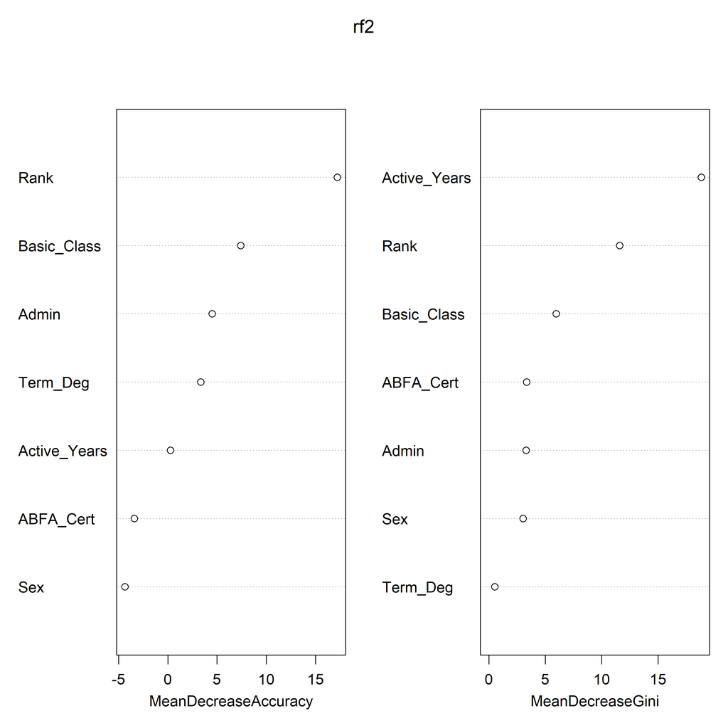

```r
## Variable Importance
varImpPlot(rf2)
```

```r
importance(rf2,type=2)
```

```
##              MeanDecreaseGini
## Sex                  3.022063
## ABFA_Cert            3.342450
## Term_Deg             0.506542
## Basic_Class          5.962275
## Rank                11.587805
## Admin                3.304103
## Active_Years        18.843709
```

### Applied FAs Only

```r
app <- filter(RFM, Type=="Applied")
app <- app[,c(1:3,5,9:10)]

summary(app)
```

```
##  Sex    ABFA_Cert Term_Deg Lab_Time   Active_Years     SI_Cat
##  F:18   N:23      MA :12   NA  : 0   Min.   : 1.00   One  :19
##  M:19   Y:14      PhD:25   Part:19   1st Qu.: 7.00   Two  :13
##                            Full:18   Median :14.00   Three: 4
##                                      Mean   :16.78   Four : 1
##                                      3rd Qu.:23.00
##                                      Max.   :46.00
```

#### RandomForest of Applied FAs only

```
## mtry = 2  OOB error = 48.65%
## Searching left ...
## Searching right ...
## mtry = 3     OOB error = 40.54%
## 0.1666667 0.01
## mtry = 4     OOB error = 37.84%
## 0.06666667 0.01
## mtry = 5     OOB error = 37.84%
## 0 0.01
```

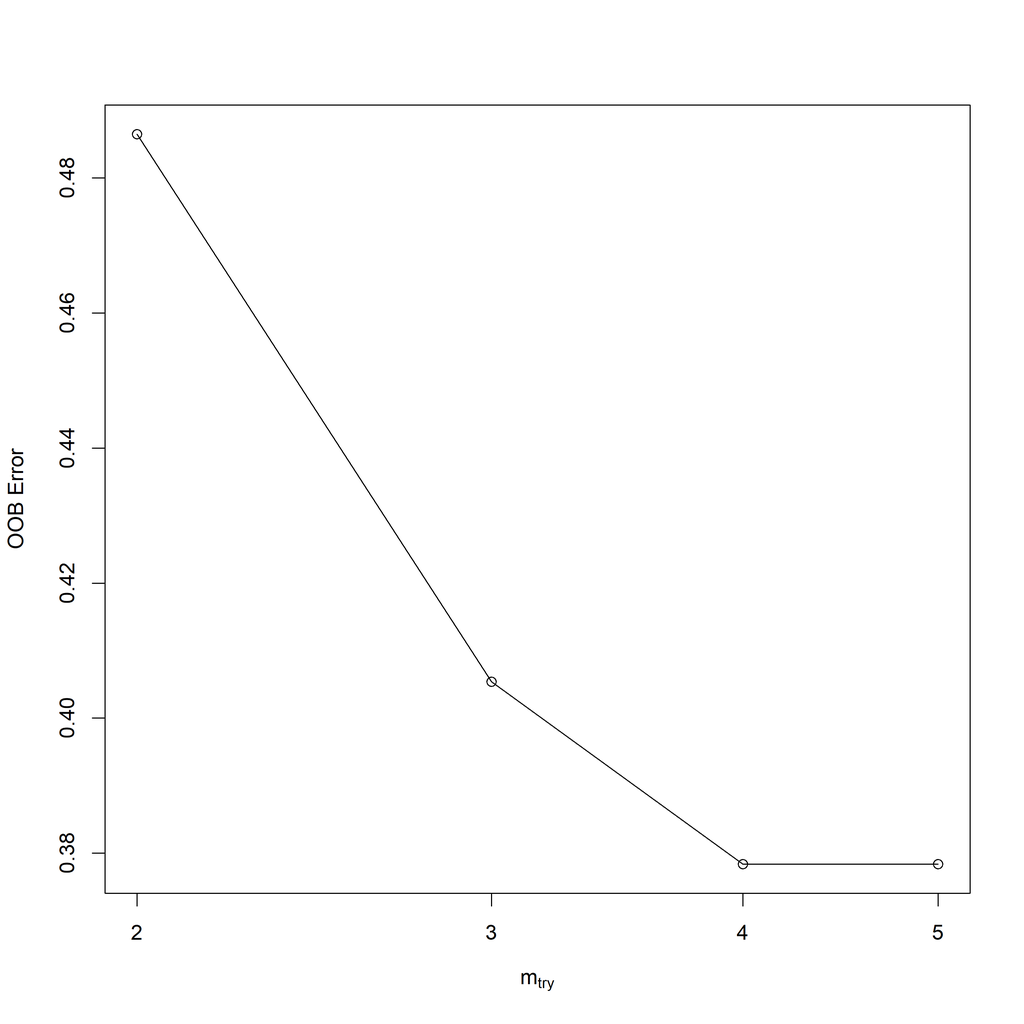

```r
set.seed(123)

## Select best mtry value
mtry3 <- tuneRF(app[,-6],app$SI_Cat,ntreeTry=500,stepFactor=1.5,improve=0.01,trace=TRUE,plot=TRUE)
```

```r
best.m3 <- mtry3[mtry3[,2]==min(mtry3[,2]),1]
print(mtry3)
```

```
##       mtry  OOBError
## 2.OOB    2 0.4864865
## 3.OOB    3 0.4054054
## 4.OOB    4 0.3783784
## 5.OOB    5 0.3783784
```

```r
print(best.m3)
```

```
## 4.OOB 5.OOB
##     4     5
```

```r
set.seed(123)
rf3 <- randomForest(SI_Cat ~., data=app, importance=TRUE, mtry=4, ntree=500)
print(rf3)
```

```
##
## Call:
##  randomForest(formula = SI_Cat ~ ., data = app, importance = TRUE,      mtry = 4, ntree = 500)
##                Type of random forest: classification
##                      Number of trees: 500
## No. of variables tried at each split: 4
##
##         OOB estimate of  error rate: 37.84%
## Confusion matrix:
##       One Two Three Four class.error
## One    15   3     1    0   0.2105263
## Two     4   8     1    0   0.3846154
## Three   3   1     0    0   1.0000000
## Four    0   1     0    0   1.0000000
```

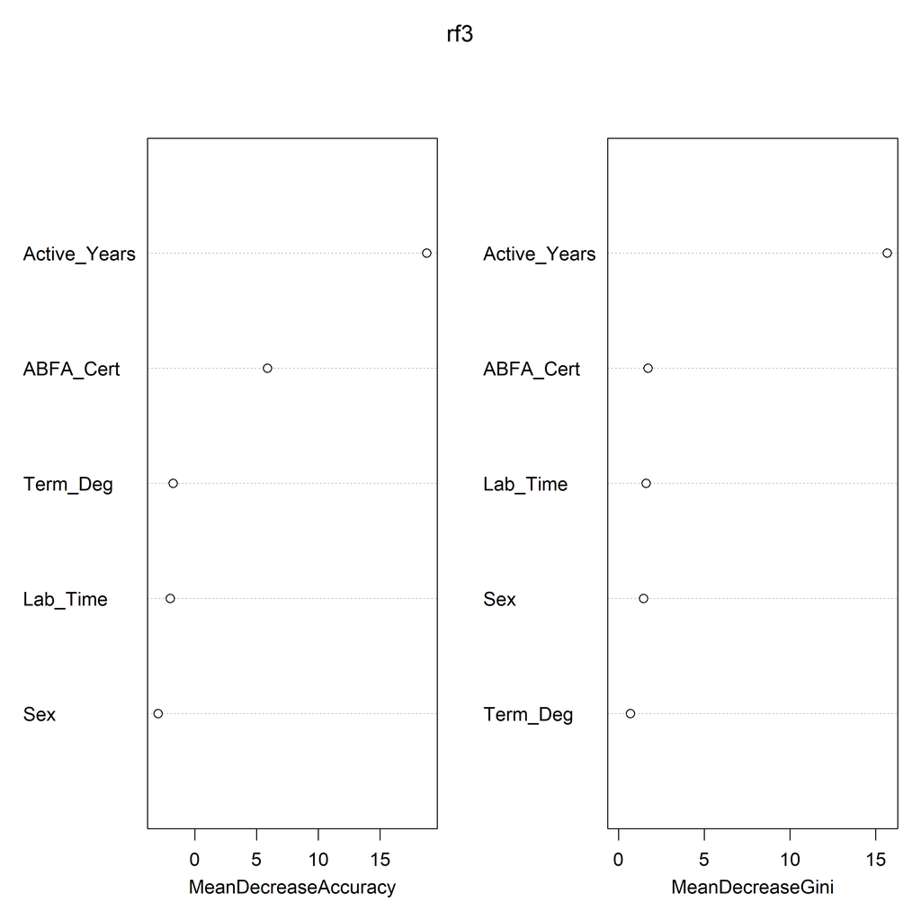

```r
## Variable Importance
varImpPlot(rf3)
```

```r
importance(rf3, type=2)
```

```
##              MeanDecreaseGini
## Sex                 1.4607527
## ABFA_Cert           1.7189859
## Term_Deg            0.6944576
## Lab_Time            1.6025965
## Active_Years       15.6634971
```

This means that the only really differentiating variable for applied FAs is the number of years they have been in the field.

## FAs vs All Academic Anthropologists

Now, we want to comare the academic FAs to all other types of academic Anthropologists.

Since we already have the All Anthros dataset imported, we will take a look at the data and then continue.

```r
summary(all)
```

```
##  Sex                               Basic_Class                   Rank
##  F:346   Special Focus Four-Year         : 19   Term               : 79
##  M:332   Associate's Colleges            :  3   Assistant Professor:145
##          Baccalaureate College           : 14   Associate Professor:196
##          Master's Colleges & Universities:127   Full Professor     :238
##          Doctoral Universities           :515   Special Rank       : 20
##
##  Admin          Subfield    Salary_Index      SI_Cat
##  0:508   Archaeology:181   Min.   : 14.58   Four :170
##  1:170   Biological :150   1st Qu.: 69.31   One  :170
##          Cultural   :254   Median : 90.61   Three:169
##          Forensic   : 77   Mean   : 94.64   Two  :169
##          Linguistic : 16   3rd Qu.:110.87
##                            Max.   :451.12
```

Now, we want to see what’s up with the correlations between variables and SI Category.

```r
## SI_Cat and Sex
SI_Sex <- rbind(c(119,184),c(190,148),c(23,15))  # contingency table
cramerV(SI_Sex, ci=TRUE)
```

```
##   Cramer.V lower.ci upper.ci
## 1   0.1739   0.1062   0.2496
```

```r
## SI_Cat and Basic_Class
SI_BC <- rbind(c(14,0,13,81,33),c(6,3,1,41,287),c(0,0,0,5,195))  # contingency table
cramerV(SI_BC, ci=TRUE)
```

```
##   Cramer.V lower.ci upper.ci
## 1   0.4655       NA       NA
```

```r
## SI_Cat and Rank
SI_Rank <- rbind(c(78,107,73,45,0),c(2,38,121,172,5),c(0,0,2,21,15))  # contingency table
cramerV(SI_Rank, ci=TRUE)
```

```
##   Cramer.V lower.ci upper.ci
## 1   0.5463    0.477   0.6251
```

```r
## SI_Cat and Admin
SI_Admin <- rbind(c(253,50),c(237,101),c(19,19))  # contingency table
cramerV(SI_Admin, ci=TRUE)
```

```
##   Cramer.V lower.ci upper.ci
## 1   0.2053   0.1375   0.2849
```

```r
## SI_Cat and Subfield
SI_Sub <- rbind(c(68,81,103,11,40),c(71,89,140,3,35),c(11,11,11,2,3))  # contingency table
cramerV(SI_Sub, ci=TRUE)
```

```
##   Cramer.V lower.ci upper.ci
## 1  0.09534  0.07851   0.1747
```

Subfield has the lowest v value with SI Category!

Next, we are going to run randomForest again, to see the variable importance and look at how much variance in SI Category can be explained by our variables. This time, we will split our training and test set by 80-20.

### Random Forest - All Academics

```r
RFM2 <- all[,c(1:5,7)]

set.seed(123)
trainIdx2 <- createDataPartition(RFM2$SI_Cat, p=0.80, list=FALSE, times=1)  # create break for training and testing data
RFM2Train <- RFM2[trainIdx2,]  # training set
RFM2Test <- RFM2[-trainIdx2,]  # testing set

set.seed(123)
## Select best mtry value
mtry4 <- tuneRF(RFM2Train[,c(1:5)],RFM2Train$SI_Cat,ntreeTry=500,stepFactor=1.5,improve=0.01,trace=TRUE,plot=FALSE)
```

```
## mtry = 2  OOB error = 54.41%
## Searching left ...
## Searching right ...
## mtry = 3     OOB error = 54.6%
## -0.003378378 0.01
```

```r
best.m4 <- mtry4[mtry4[,2]==min(mtry4[,2]),1]
print(mtry4)
```

```
##       mtry  OOBError
## 2.OOB    2 0.5441176
## 3.OOB    3 0.5459559
```

```r
print(best.m4)
```

```
## [1] 2
```

```r
set.seed(123)
## RandomForest modeling
rf4 <- randomForest(SI_Cat~., data=RFM2Train, importance=TRUE, mtry=2, ntry=500)
print(rf4)
```

```
##
## Call:
##  randomForest(formula = SI_Cat ~ ., data = RFM2Train, importance = TRUE,      mtry = 2, ntry = 500)
##                Type of random forest: classification
##                      Number of trees: 500
## No. of variables tried at each split: 2
##
##         OOB estimate of  error rate: 54.23%
## Confusion matrix:
##       Four One Three Two class.error
## Four    93   9    19  15   0.3161765
## One     14  65    26  31   0.5220588
## Three   47  11    41  37   0.6985294
## Two     23  25    38  50   0.6323529
```

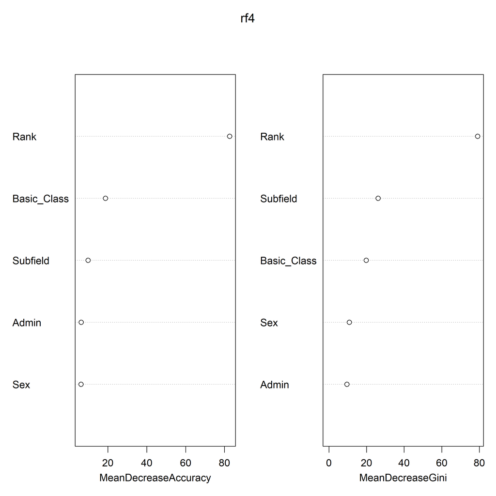

```r
## Variable Importance
varImpPlot(rf4)
```

```r
importance(rf4,type=2)
```

```
##             MeanDecreaseGini
## Sex                 10.80364
## Basic_Class         19.80911
## Rank                79.08876
## Admin                9.54725
## Subfield            26.12869
```

Now, see how the model performs on the test set:

```r
set.seed(123)
test_pred2 <- predict(rf4, RFM2Test)

cfm_all <- confusionMatrix(test_pred2, RFM2Test$SI_Cat)
cfm_all
```

```
## Confusion Matrix and Statistics
##
##           Reference
## Prediction Four One Three Two
##      Four    28   3     8   5
##      One      0  18     5   9
##      Three    3   6     9   4
##      Two      3   7    11  15
##
## Overall Statistics
##
##                Accuracy : 0.5224
##                  95% CI : (0.4344, 0.6093)
##     No Information Rate : 0.2537
##     P-Value [Acc > NIR] : 2.791e-11
##
##                   Kappa : 0.3628
##
##  Mcnemar's Test P-Value : 0.1533
##
## Statistics by Class:
##
##                      Class: Four Class: One Class: Three Class: Two
## Sensitivity               0.8235     0.5294      0.27273     0.4545
## Specificity               0.8400     0.8600      0.87129     0.7921
## Pos Pred Value            0.6364     0.5625      0.40909     0.4167
## Neg Pred Value            0.9333     0.8431      0.78571     0.8163
## Prevalence                0.2537     0.2537      0.24627     0.2463
## Detection Rate            0.2090     0.1343      0.06716     0.1119
## Detection Prevalence      0.3284     0.2388      0.16418     0.2687
## Balanced Accuracy         0.8318     0.6947      0.57201     0.6233
```

#### RFM With Salary Index for comparison

```r
RFM3 <- all[,c(1:6)]  # remove SI_Cat

set.seed(123)
trainIdx3 <- createDataPartition(RFM3$Salary_Index, p=0.8, list=FALSE, times=1)  # break
RFM3Train <- RFM3[trainIdx3,]
RFM3Test <- RFM3[-trainIdx3,]

set.seed(123)

## Select best mtry value
mtry5 <- tuneRF(RFM3Train[,c(1:5)],RFM3Train$Salary_Index,ntreeTry=500,stepFactor=1.5,improve=0.01,trace=TRUE,plot=FALSE)
```

```
## mtry = 1  OOB error = 1228.22
## Searching left ...
## Searching right ...
```

```r
best.m5 <- mtry5[mtry5[,2]==min(mtry5[,2]),1]
print(mtry5)
```

```
##   mtry OOBError
## 1    1  1228.22
```

```r
print(best.m5)
```

```
## [1] 1
```

```r
set.seed(123)
## RandomForest modeling
rf5 <- randomForest(Salary_Index~., data=RFM3Train, importance=TRUE, mtry=1, ntry=500)
print(rf5)
```

```
##
## Call:
##  randomForest(formula = Salary_Index ~ ., data = RFM3Train, importance = TRUE,      mtry = 1, ntry = 500)
##                Type of random forest: regression
##                      Number of trees: 500
## No. of variables tried at each split: 1
##
##           Mean of squared residuals: 1250.221
##                     % Var explained: 34.57
```

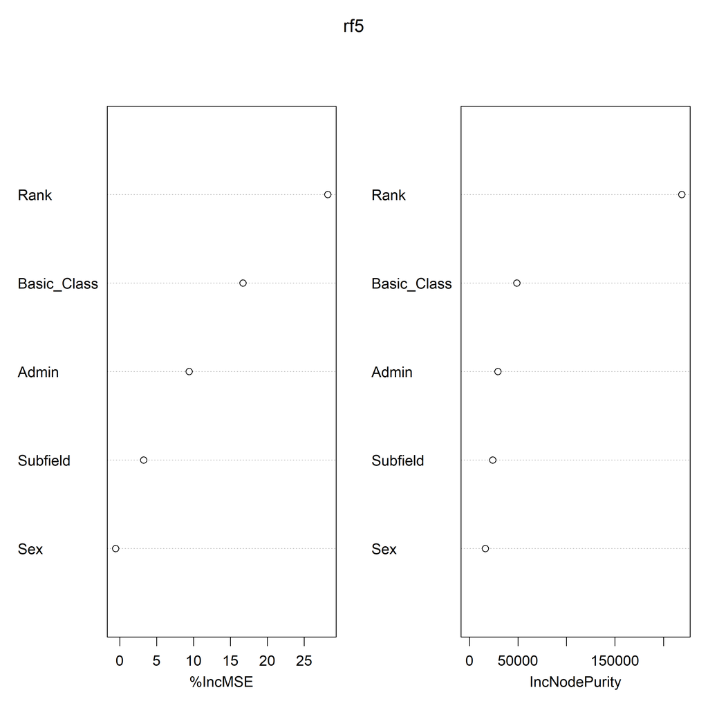

```r
## Variable Importance
varImpPlot(rf5)
```

```r
importance(rf5,type=1)
```

```
##                %IncMSE
## Sex         -0.5578454
## Basic_Class 16.7089644
## Rank        28.2084181
## Admin        9.4119074
## Subfield     3.2403209
```

```r
## Confusion Matrix
set.seed(123)
test_pred3 <- predict(rf5, RFM3Test)
icc_df <- cbind(test_pred3,RFM3Test$Salary_Index)
icc(icc_df)
```

```
##  Single Score Intraclass Correlation
##
##    Model: oneway
##    Type : consistency
##
##    Subjects = 134
##      Raters = 2
##      ICC(1) = 0.442
##
##  F-Test, H0: r0 = 0 ; H1: r0 > 0
##  F(133,134) = 2.59 , p = 3.64e-08
##
##  95%-Confidence Interval for ICC Population Values:
##   0.296 < ICC < 0.569
```

```r
rmse <- RMSE(test_pred3, RFM3Test$Salary_Index)
rmse
```

```
## [1] 33.73521
```

-END-